# Lab 5: Murder in SQL City

Author

Yanna Shirokova

Published

October 24, 2024

For this lab, you will be joining and filtering related datasets to solve a murder mystery!

## Instructions

Northwestern University’s Knight Lab wanted to help sharpen users’ database skills, so they created a murder mystery. Can you solve this crime in SQL City??

The relational data you will be working with contains tables with different pieces of information pertinent to the crime - people, social media check-ins, driver’s licenses, crime scene reports, police interviews, and more!

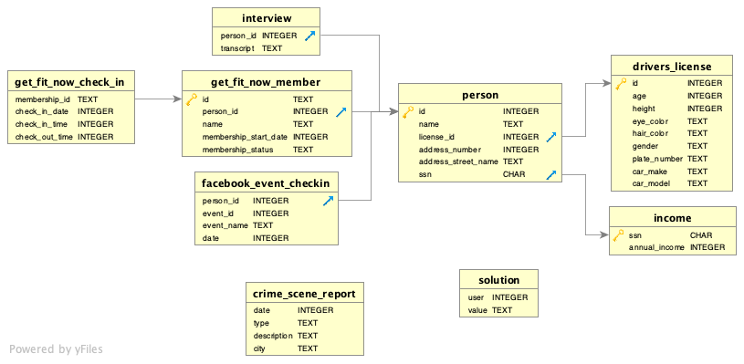

Database schema

Solve the murder mystery, showing **all of your work in this document**. Your document and code must be well organized, easy to follow, and reproducible.

- Use headers and written descriptions to indicate what you are doing.
- Use `dplyr` verbs and `join` functions rather than just looking through the tables manually.
- Use good code formatting practices.
- Comment your code.
- Cite any external sources you use to solve the mystery.

### Tips

You may find the `pull()` function handy for displaying each clue as you go along.

## Access the Data

This code chunk will read in all of the tables of data for you. Don’t modify or remove this!

```r
library(tidyverse)

# If purrr is not detected, install the package
if (!"purrr" %in% installed.packages()) install.packages("purrr")

source("https://raw.githubusercontent.com/atheobold/groupworthy-data-science/main/labs/instructions/lab-5-setup.R")
```

## Solve the Crime

### Crime Scene Report

Detective Wickham reaches out to you…

> A crime has taken place and I need your help! There was a murder in SQL City sometime on January 15, 2018. Could you retrieve the crime scene report from the police department’s database and follow the clues to find the person responsible for the murder?!

**Follow the evidence to the person responsible for the murder, building a report as you go.** Hint: Make sure you check for interviews with any suspects!

```r
# Look at first clues
# Murder
# Jan 15, 2018
# SQL city
crime_scene_report |>
  mutate(date = ymd(date)) |>
  filter(city == "SQL City",
         type == "murder",
         date == ymd(20180115)) |>
  select(description)
```

```
# A tibble: 1 × 1
  description
  <chr>
1 "Security footage shows that there were 2 witnesses. The first witness lives …
```

### Looking at Witnesses

```r
# Lets find witnesses and look at their interviews
# Clues:
# The first witness lives at the last house on "Northwestern Dr"
# The second witness, named Annabel, lives somewhere on "Franklin Ave"

person |>
  filter(
    (address_street_name == "Northwestern Dr" &
     address_number == max(address_number)) |
    (str_detect(name, "Annabel") &
    address_street_name == "Franklin Ave")) |>
  left_join(interview, by = c("id" = "person_id")) |>
  select(transcript)
```

```
# A tibble: 2 × 1
  transcript
  <chr>
1 "I heard a gunshot and then saw a man run out. He had a \"Get Fit Now Gym\" b…
2 "I saw the murder happen, and I recognized the killer from my gym when I was …
```

### Finding The Inital Suspect and Interview

```r
# Lets see what we can find from the interviews

# Clues:
# The membership number on the bag started with "48Z"
# I was working out last week on January the 9th
membership_ids <- get_fit_now_check_in |>
  filter(str_detect(membership_id, "^48Z"),
         ymd(check_in_date) == ymd("2018-01-09")) |>
  select(membership_id)

# Clue: The man got into a car with a plate that included "H42W"
driver_ids <- drivers_license |>
  filter(gender == "male",
         str_detect(plate_number, "H42W")) |>
  select(id) |>
  rename(license_id = id)

# Find the person id from driver_ids (above)
person_ids <- driver_ids |>
  inner_join(person, by = "license_id") |>
  select(id)

# Join on the person id from person_ids (above)
# Join on the membership_ids (above)
# Clue: Only gold members have those bags.
# Find the suspect and interview!
get_fit_now_member |>
  inner_join(person_ids, by = c("person_id" = "id")) |>
  inner_join(membership_ids, by = c("id" = "membership_id")) |>
  filter(membership_status == "gold") |>
  inner_join(interview, by = "person_id") |>
  select(name, transcript)
```

```
# A tibble: 1 × 2
  name          transcript
  <chr>         <chr>
1 Jeremy Bowers "I was hired by a woman with a lot of money. I don't know her n…
```

### Finding the Murderer

```r
# GROWING/ REFLECTION: In my original lab, I missed this whole step! I just
# found who did the murdering (Jeremy Bowers), but not the mind behind the
# murder. Above, I added an inner_join (with interview data) at the end to see
# the transcript from our initial suspect! I got many more clues. By adding these
# changes I was able to find the actual murderer, which was Miranda Priestly. I
# also confirmed she was the murderer by looking at her interview, which
# she doesn't! This was important code to add as I didn't find the actual
# murderer before.

# Transcript/ Clues (from above):
# I was hired by a woman with a lot of money. I don't know her name but
# I know she's around 5'5" (65") or 5'7" (67"). She has red hair and she
# drives a Tesla Model S. I know that she attended the SQL Symphony Concert
# 3 times in December 2017.
drivers_license |>
  rename(license_id = id) |>
  filter(
    gender == "female",
    hair_color == "red",
    height >= 65 & height <= 67,
    car_make == "Tesla",
    car_model == "Model S"
  ) |>
  left_join(person, by = "license_id") |>
  inner_join(facebook_event_checkin, by = c("id" = "person_id")) |>
  # since date is a double, change to character first
  filter(str_starts(as.character(date), "2017"),
         event_name == "SQL Symphony Concert") |>
  group_by(id) |>
  summarise(event_count = n(), .groups = "drop") |>
  filter(event_count == 3) |>
  inner_join(person, by = "id") |>
  left_join(interview, by = c("id" = "person_id")) |>
  # Confirm new suspect = shouldn't have an interview
  select(name, transcript)
```

```
# A tibble: 1 × 2
  name             transcript
  <chr>            <chr>
1 Miranda Priestly <NA>
```

## And the final suspect is…

*Put the name of the person responsible for the murder here:* Miranda Priestly!